# R exercise for GeneCentric

J. Usary

November 2019

**This R markdown document is an answer to the exercise provided by GeneCentric to assess coding capability.**  
The exercise has three parts:  
1. Read expression data  
2. Determine lung adenocarcinoma subtype  
3. Association between T cells and subtype  
Before beginning, install the needed R packages

```r
if (!require("dplyr")) {
   install.packages("dplyr")
   library(dplyr)
}
```

### 1. Read expression data

Download TCGA lung adenocarcinoma expression matrix from the firehose website. http://firebrowse.org/?cohort=LUAD&download_dialog=true

```r
# Read data file
seqData <- read.csv("Data/LUAD.rnaseqv2__illuminahiseq_rnaseqv2__unc_edu__Level_3__RSEM_genes_normalized__data.data.csv",stringsAsFactor = FALSE, header = TRUE)

# Adjust the data
seqData <- seqData[-c(1:29),]       # remove the genes with no names.
seqData[16273,1]<- "SLC35E2*|9906"  # edit duplicate gene name "SLC35E2".

# Fix the gene names column
fullNames  <- seqData$X                  # put the row names in a vector as characters
geneNames <- gsub("\\|.*","",fullNames)  # remove part after the "|" charcter in the full gene name.
rownames(seqData) <- geneNames
```

Keep solid tumor samples only. These samples have “01” for the 14th and 15th characters in the ID. n=515 solid tumors.

```r
sampleNames <- colnames(seqData)  # put the column names in a vector as characters.
sampleChars <- substr(sampleNames, 14, 15)  # select and puts the right numbers as chars in a vector.
sampleNumbers <- sampleChars <- as.numeric(sampleChars) # change the chars to numeric.
sampleNumbers[1]  <-1  # change the NA in position 1 to number 1 so gene names column will be selected also.
solidTumors  <- seqData[, sampleNumbers == 1]  # select the solid tumors only into a new data frame.
```

Transform the expression values log2(RSEM+1) and use for the work below.

```r
log2data  <- log2(solidTumors[ ,-1] +1) # remove column of gene names, add one to remove negative values, and log2 transform the data.
```

### 2. Determine lung adenocarcinoma subtype

Open centroid classifier with 3 centroids and 506 genes.

```r
centroid <- read.csv("Data/wilkerson.2012.LAD.predictor.centroids.csv",stringsAsFactor = FALSE, header = TRUE)
```

Find all subtyper genes available in the TCGA dataset.

```r
centroidNames <- as.character(centroid [,1])
common  <- centroidNames [centroidNames %in% geneNames ]    # 489 genes are common.
missing <- centroidNames [!(centroidNames %in% geneNames )] #  17 genes are missing.
```

Report which of the 506 are not there.

```r
write(missing, file = "missingCentroidGenes.txt")
missing
```

```
##  [1] "CDC2"          "DLG7"          "GGTLA4"        "PBEF1"
##  [5] "HIG2"          "DKFZp762E1312" "DRAM"          "ATAD4"
##  [9] "GLULD1"        "CXorf9"        "HMG4L"         "P15RS"
## [13] "RBM35A"        "DKFZP564O0823" "INDO"          "GOLSYN"
## [17] "LOC26010"
```

```r
# REPORT file created
```

In the TCGA n=515 data set, center each gene using the gene median.

```r
dataMedianCentered  <- log2data-apply(log2data,1,median,na.rm=T)  # median center by rows(genes).
```

To determine subtype for a given sample find the centroid it is closest to, using correlation to measure distance. Calculate the Pearson correlation coefficient between each sample and each centroid using all available genes.

```r
# Select gene rows from the data that match the centroid gene names list
subtypeGenesData  <- dataMedianCentered [common,]

# Select only the centroid subtype data for genes that are common and add selected data to the TCGA data file
rownames(centroid) <- centroid$name  # set first column to be row names.
centroidDataInTCGA <- centroid[common,]

# Merge the centriod data and the sample data
mergedCentroidSampleData  <- cbind(centroidDataInTCGA[,-1], subtypeGenesData )

# Perform Pearson Correlation Coefficient calculations
DATAcorrMatrixSubtype0 <- cor(mergedCentroidSampleData)
DATAcorrMatrixSubtype  <- t(DATAcorrMatrixSubtype0[1:3,4:518]) # transpose data and Select desired rows and columns.
```

Then for any sample, subtype is defined as the label of the centroid it is closest to. Report sample id, subtype in a csv.

```r
calls<-apply(DATAcorrMatrixSubtype,1,which.max) # choose largest correlations.
sampleCalls <- colnames(DATAcorrMatrixSubtype)[calls] # associate number with subtype.
sampleNames <- names(calls)
subtypeCalls <- cbind(sampleNames, sampleCalls)
write.csv(subtypeCalls, file = "subtypeCalls.csv", row.names=TRUE)
# REPORT file created
```

### 3. Association between T cells and subtype

For each sample, calculate the T cells signature as the average expression level across all available genes in the signature. Report any genes in the signature that weren’t used because they weren’t in TCGA.

19 genes in the T cells signature: PRKCQ, CD3D, CD3G, CD28, LCK, TRAT1, BCL11B, CD2, TRBC1, TRAC, ITM2A, SH2D1A, CD6, CD96, NCALD, GIMAP5, TRA, CD3E, and SKAP1.

```r
TsigNames <- c("PRKCQ", "CD3D", "CD3G", "CD28", "LCK", "TRAT1", "BCL11B",
               "CD2", "TRBC1", "TRAC", "ITM2A", "SH2D1A", "CD6", "CD96",
               "NCALD", "GIMAP5", "TRA", "CD3E", "SKAP1")

common2  <- TsigNames [TsigNames %in% geneNames ]
missing2 <- TsigNames [!(TsigNames %in% geneNames )]

write(missing2, file = "missingTSigGenes.txt")
# REPORT file created
```

Plot T cells signature (y-axis) vs subtype (x-axis) using boxplots in a pdf.

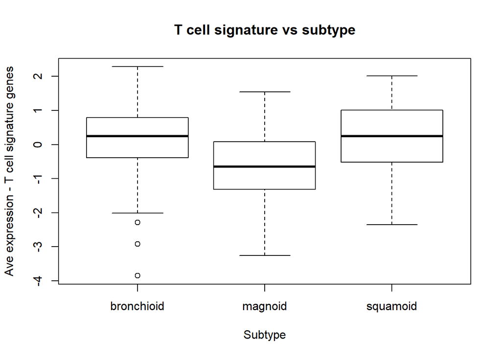

```r
# Select gene rows from the data that match the TSig gene names list
z  <- dataMedianCentered[common2,]
z2 <- colMeans(z, na.rm = FALSE, dims = 1)

# Create and save boxplot
boxplot(z2~sampleCalls,data=subtypeCalls, main=" T cell signature vs subtype ", xlab="Subtype", ylab="Ave expression - T cell signature genes")
```

```r
pdf("T-cell-signature-vs-subtype.pdf")
# REPORT file created
```

Test whether subtype is associated with T cells using the Kruskal-Wallis test and report the p-value only.

```r
r  <- cbind(z2, subtypeCalls) # tie the files together.
s  <-kruskal.test(z2 ~ sampleCalls, data = subtypeCalls)
print(paste("The p-value for the Kruskal-Wallis rank sum test is",s$p.value))
```

```
## [1] "The p-value for the Kruskal-Wallis rank sum test is 2.71407736076808e-16"
```

**Report files created:**  
“missingCentroidGenes.txt”  
“missingTSigGenes.txt”  
“subtypeCalls.csv”  
“T-cell-signature-vs-subtype.pdf”